# R Notebook

Esse notebook foi utilizado para a criação do artigo da disciplina MAE5870 de Séries Temporais.

```r
install.packages("openxlsx")
install.packages("dplyr")
install.packages("lubridate")
install.packages("car")
install.packages("forecast")
install.packages("glarma")
install.packages("lmtest")
```

```r
library(openxlsx)
library(dplyr)
library(lubridate)
library(car)
library(forecast)
library(glarma)
library(lmtest)
```

```r
data <- read.xlsx("../resources/incendios-florestais-em-areas-protegidas-boi-areas-protegidas-2019-marco.xlsx", sheet = 1)

data$DataHoraDeteccao <- convertToDate(data$DataHoraDeteccao)
data$DataDeteccao <- convertToDate(data$DataDeteccao)
data$InicioCombate <- convertToDate(data$InicioCombate)
data$TerminoCombate <- convertToDate(data$TerminoCombate)
```

```r
min(data$DataDeteccao); max(data$DataDeteccao)
```

```
[1] "2019-01-04"
[1] "2025-12-09"
```

```r
day_agg_df <- data |> group_by(day=floor_date(DataDeteccao, "day")) |> summarise(qty = n_distinct(NumBOI))
day_y <- ts(day_agg_df[,2], start=c(2019,1,4), frequency = 1)
```

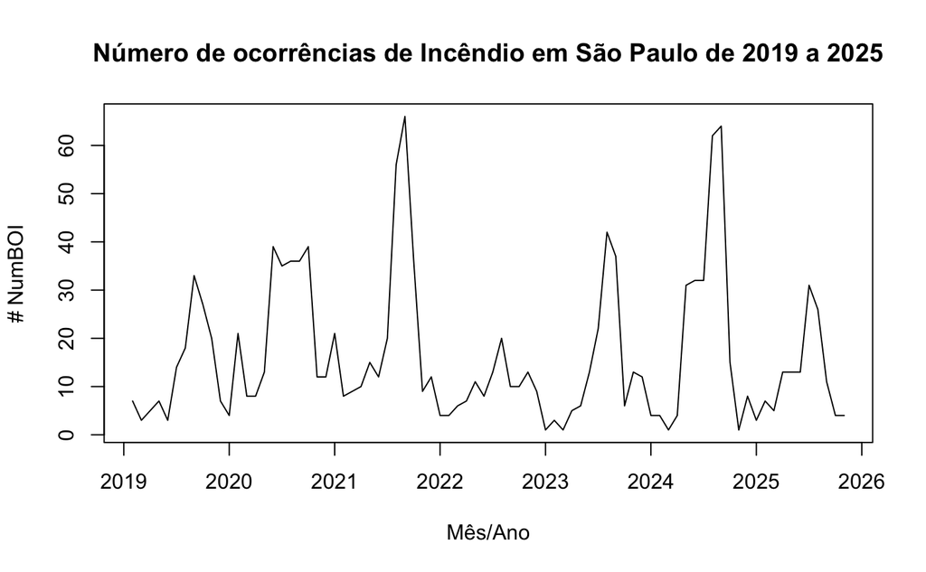

```r
ts.plot(y, xlab="Mês/Ano", ylab="# NumBOI", main="Número de ocorrências de Incêndio em São Paulo de 2019 a 2025")
```

```r
agg_df <- data |> group_by(month_year=floor_date(DataDeteccao, "month")) |> summarise(qty = n_distinct(NumBOI))
```

```r
y <- ts(agg_df[,2], start=c(2019,2), end=c(2025,11), frequency = 12)
```

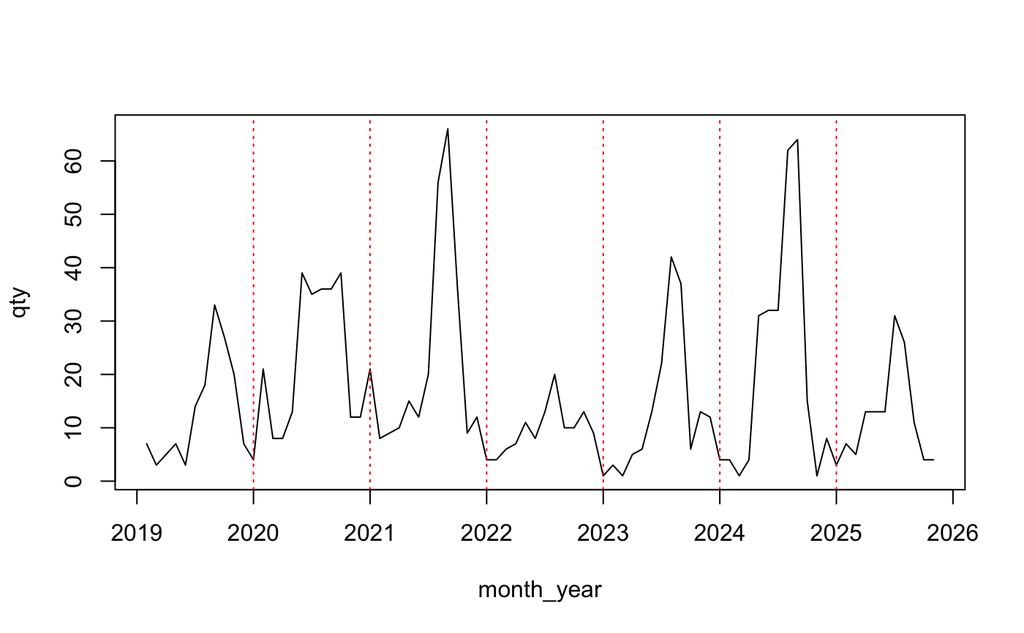

```r
n_months = 12
ts.plot(y, xlab="month_year", ylab="qty"); abline(v = time(y)[seq(n_months, length(y), by = n_months)], col = "red", lty = 3)
```

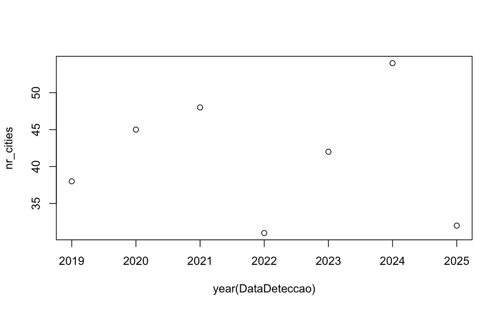

```r
plot(data |> group_by(year(DataDeteccao)) |> summarise(nr_cities = n_distinct(NomMunicipio)))
```

```r
mean(y); var(y[,1])
```

```
[1] 16.40244
[1] 227.5521
```

A imagem acima apresenta a série temporal de Incêndios Florestais em São Paulo de 2019 até final de 2025. Destaca-se a tendência positiva entre os meses de maio e setembro, seguido de uma queda, além de uma repetição sazonal anual aparente. Nota-se também que a mesma não é estacionária.

Adiciona-se um gráfico sobre o comportamento do número de cidades que apresentaram registros de ocorrência de incêndio ao longo dos anos explorados. Nota-se uma ano- malia para o ano de 2022, resultado do fenômeno La Niña.

Voltando a série principal, aplicarei a diferenciação no lag 12 para avaliar se a tendência se mantém.

```r
mean(diff(y, 12)); var(diff(y[,1], 12))
```

```
[1] -0.1428571
[1] 286.1822
```

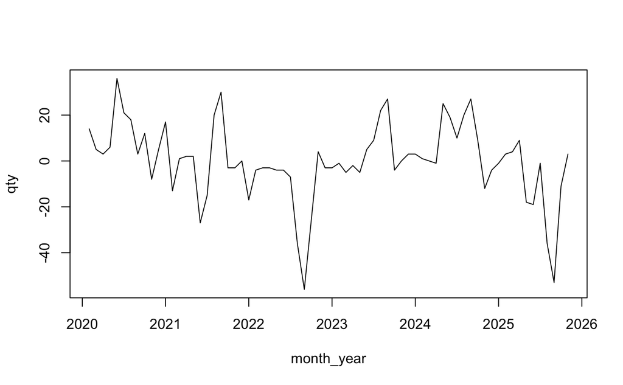

```r
ts.plot(diff(y, 12), xlab="month_year", ylab="qty")
```

O gráfico acima apresenta uma tendência levemente decrescente. Antes de seguirmos para a análise das funções de autocorrelação (total - ACF e parcial - PACF), efetuaremos uma nova diferenciação.

```r
diff_y_both_12_and_1 <- diff(diff(y, 12), 1)
```

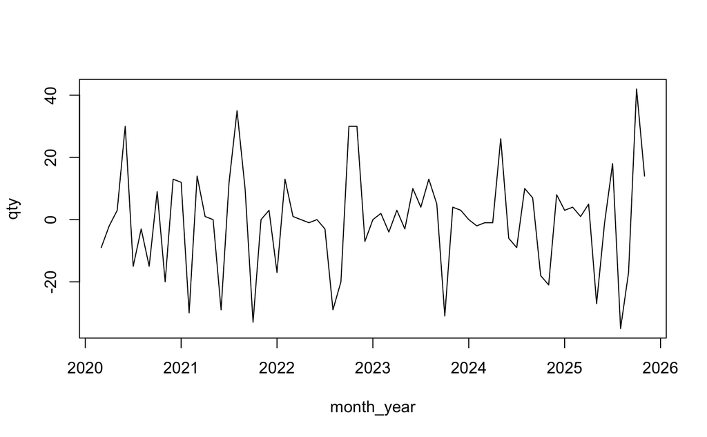

```r
ts.plot(diff_y_both_12_and_1, xlab="month_year", ylab="qty")
```

```r
mean(diff_y_both_12_and_1); var(diff_y_both_12_and_1[,1])
```

```
[1] -0.1594203
[1] 264.6948
```

Após essa diferenciação dupla perde-se a tendência vista na imagem anterior, a série passa a ter média próxima de 0 e variância ao redor de 264. Analisarei os gráficos da função de autocorrelação (total - ACF e parcial - PACF) a seguir.

```r
par(mfrow = c(1, 2), mar = c(8, 2, 4, 2))
acf(diff_y_both_12_and_1, main="ACF")
pacf(diff_y_both_12_and_1, main="PACF")
```

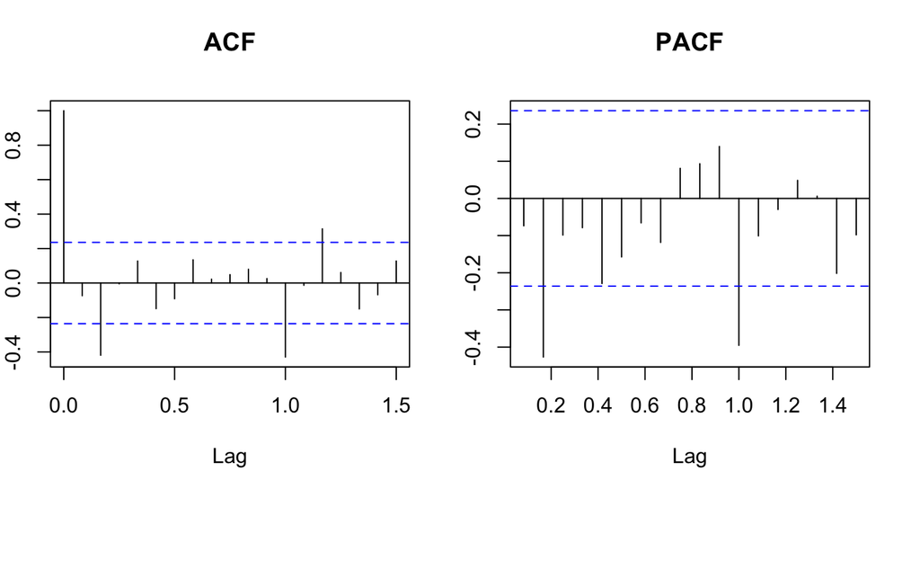

```r
par(mfrow=c(1,1))
```

O gráfico de ACF apresenta lags relevantes no instante 2, além de uma rein- cidência no lag 12. De fato existe sazonalidade com frequência de 12 meses. Com base neste gráfico definiremos o valor dos parâmetros q e Q referente ao componente de média móvel.

Já o gráfico de PACF também apresenta lags relevantes no instante 2 e reincidên- cia no lag 12. Vale destacar, entretanto, que os lags posteriores a 2 tem tendência decrescente de forma lenta. Com base neste gráfico definiremos o valor dos parâmetros p e P referente ao componente de auto regressão.

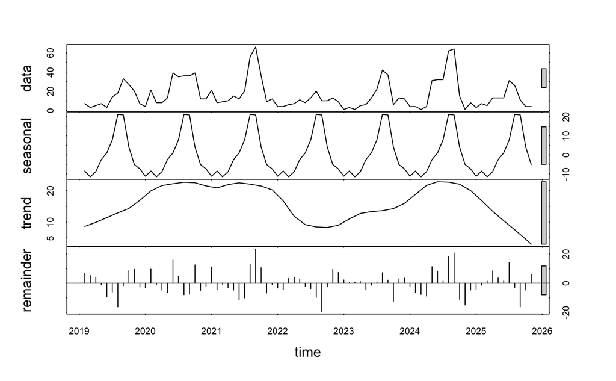

```r
plot(stl(y[,1], s.window="periodic"))
```

# Modeling

## SARIMA(0,1,2)(1,1,1)12

```r
sarima_model <- arima(y, order=c(0,1,2), seasonal=list(order=c(1,1,1), period=12), fixed=c(NA, NA, 0, NA))
sarima_model
```

```
Call:
arima(x = y, order = c(0, 1, 2), seasonal = list(order = c(1, 1, 1), period = 12),
    fixed = c(NA, NA, 0, NA))

Coefficients:
          ma1      ma2  sar1     sma1
      -0.2488  -0.4898     0  -1.0000
s.e.   0.1100   0.1126     0   0.3813

sigma^2 estimated as 88.66:  log likelihood = -264.59,  aic = 537.17
```

```r
coeftest(sarima_model)
```

```
z test of coefficients:

     Estimate Std. Error z value Pr(>|z|)
ma1  -0.24882    0.11003 -2.2614 0.023737 *
ma2  -0.48981    0.11255 -4.3518 1.35e-05 ***
sma1 -0.99998    0.38134 -2.6223 0.008734 **
---
Signif. codes:  0 ‘***’ 0.001 ‘**’ 0.01 ‘*’ 0.05 ‘.’ 0.1 ‘ ’ 1
```

```r
coef(sarima_model)
```

```
       ma1        ma2       sar1       sma1
-0.2488174 -0.4898092  0.0000000 -0.9999779
```

```r
aa_model <- auto.arima(y)
summary(aa_model)
```

```
Series: y
ARIMA(0,0,1)(2,1,0)[12]

Coefficients:
         ma1     sar1     sar2
      0.5595  -0.8121  -0.6514
s.e.  0.1002   0.1042   0.0904

sigma^2 = 83.69:  log likelihood = -261.22
AIC=530.44   AICc=531.05   BIC=539.43

Training set error measures:
                      ME     RMSE      MAE       MPE    MAPE      MASE       ACF1
Training set -0.05743395 8.269265 5.716617 -38.68762 64.9898 0.4964804 0.03068923
```

```r
coeftest(aa_model)
```

```
z test of coefficients:

      Estimate Std. Error z value  Pr(>|z|)
ma1   0.559526   0.100236  5.5821 2.377e-08 ***
sar1 -0.812070   0.104206 -7.7930 6.546e-15 ***
sar2 -0.651416   0.090411 -7.2051 5.801e-13 ***
---
Signif. codes:  0 ‘***’ 0.001 ‘**’ 0.01 ‘*’ 0.05 ‘.’ 0.1 ‘ ’ 1
```

```r
par(mfrow=c(1,2), mar=c(8,2,4,2))
acf(sarima_model$residuals, main="ACF SARIMA(0,1,2)(1,1,1)12")
acf(aa_model$residuals, main="ACF SARIMA(0,0,1)(2,1,0)12")
```

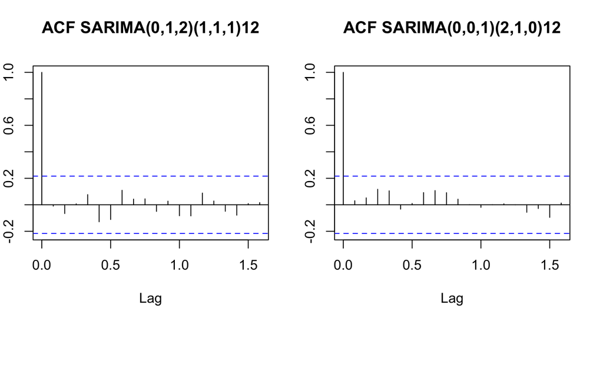

```r
par(mfrow=c(1,1))
```

```r
par(mfrow=c(1,2), mar=c(8,2,4,2))
qqPlot(sarima_model$residuals, main="qqplot SARIMA(0,1,2)(1,1,1)12")
```

```
[1] 64 31
```

```r
qqPlot(aa_model$residuals, main="qqplot SARIMA(0,0,1)(2,1,0)12")
```

```
[1] 44 57
```

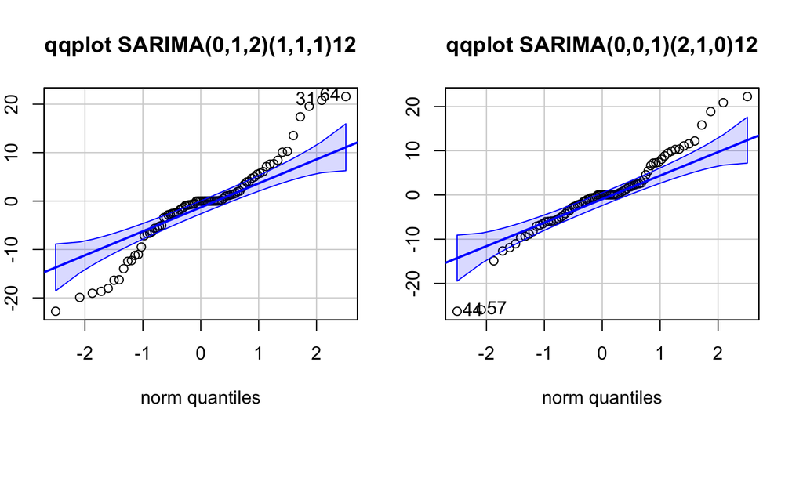

```r
par(mfrow=c(1,1))
```

```r
Box.test(sarima_model$residuals, lag = 15, type = "Ljung-Box")
```

```
    Box-Ljung test

data:  sarima_model$residuals
X-squared = 7.5406, df = 15, p-value = 0.9409
```

```r
Box.test(aa_model$residuals, lag = 15, type = "Ljung-Box")
```

```
    Box-Ljung test

data:  aa_model$residuals
X-squared = 5.4495, df = 15, p-value = 0.9876
```

```r
ci <- 1.96

custom_sarima_forecast <- predict(sarima_model, n.ahead = 12)

custom_sarima_upper_bound <- custom_sarima_forecast$pred + ci * custom_sarima_forecast$se
custom_sarima_lower_bound <- custom_sarima_forecast$pred - ci * custom_sarima_forecast$se

aarima_forecast <- predict(aa_model, n.ahead = 12)

aarima_upper_bound <- aarima_forecast$pred + ci * aarima_forecast$se
aarima_lower_bound <- aarima_forecast$pred - ci * aarima_forecast$se

par(mfrow = c(1, 2), mar = c(8, 2, 4, 2))
ts.plot(y, (y - residuals(sarima_model)), custom_sarima_forecast$pred, custom_sarima_upper_bound, custom_sarima_lower_bound, xlab="mês/ano", ylab="qty", lty=c(1,2,1,3,3), col=c("black", "red", "blue", "gray", "gray"), main="Previsão SARIMA(0,1,2)(1,1,1)12"); abline(h = 0, col = "black", lty = 4, lwd = 1)
legend("topleft",
       legend = c("observado", "previsto", "projetado"),
       col = c("black", "red", "blue"),
       lty = c(1, 2, 1),
       cex=0.5)
```

```r
ts.plot(y, (y - residuals(aa_model)), aarima_forecast$pred, aarima_upper_bound, aarima_lower_bound, xlab="mês/ano", ylab="qty", lty=c(1,2,1,3,3), col=c("black", "red", "blue", "gray", "gray"), main="Previsão SARIMA(0,0,1)(2,1,0)12"); abline(h = 0, col = "black", lty = 4, lwd = 1)
legend("topleft",
       legend = c("observado", "previsto", "projetado"),
       col = c("black", "red", "blue"),
       lty = c(1, 2, 1),
       cex=0.5)
```

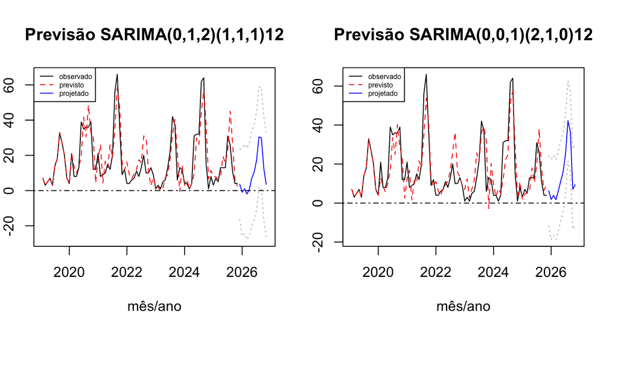

```r
par(mfrow = c(1,1))
```

Como notamos nos plots de previsão de ambos os modelos gerados, alguns tempos t contaram com valores abaixo de 0.

Buscando contornar essa situação, efetuarei o estudo da série aplicando a trans- formação log(valor+1) e avaliarei os gráficos da série para identificação de um novo modelo para competir com o auto.arima.

```r
transformed_y <- log(y + 1)
```

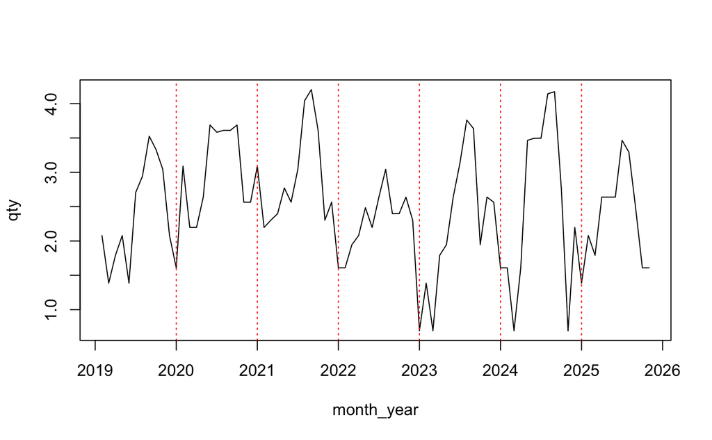

```r
n_months = 12
ts.plot(transformed_y, xlab="month_year", ylab="qty"); abline(v = time(transformed_y)[seq(n_months, length(transformed_y), by = n_months)], col = "red", lty = 3)
```

```r
diff_transformed_y <- diff(diff(transformed_y, 12), 1)
```

```r
par(mfrow = c(1, 2), mar = c(8, 2, 4, 2))
ts.plot(diff(transformed_y, 12), xlab="mês/ano", ylab="qty", main="diff_12")
ts.plot(diff_transformed_y, xlab="mês/ano", ylab="qty", main="diff_12 > diff_1")
```

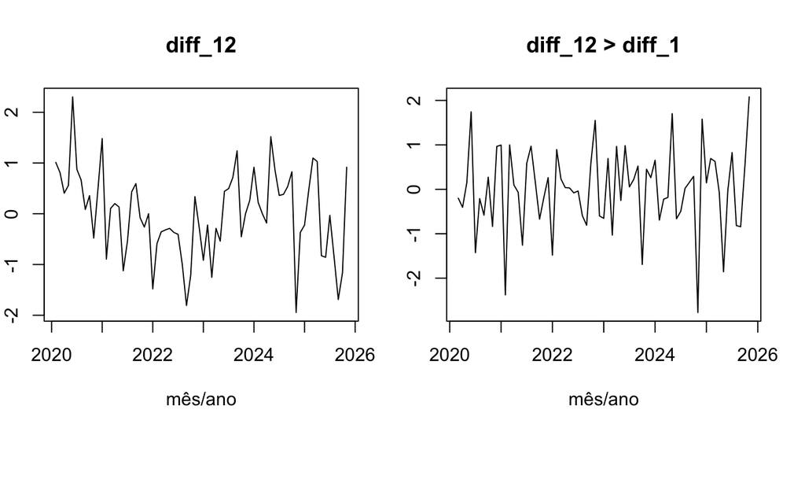

```r
par(mfrow = c(1, 1))
```

```r
par(mfrow = c(1, 2), mar = c(8, 2, 4, 2))
acf(diff_transformed_y, main="ACF (série transformada)")
pacf(diff_transformed_y, main="PACF (série transformada)")
par(mfrow = c(1, 1))
```

[output not shown]

```r
par(mfrow = c(1, 2), mar = c(8, 2, 4, 2))
acf(diff_transformed_y, main="ACF (série transformada)", lag.max=24)
acf(diff_y_both_12_and_1, main="ACF (série original)", lag.max=24)
```

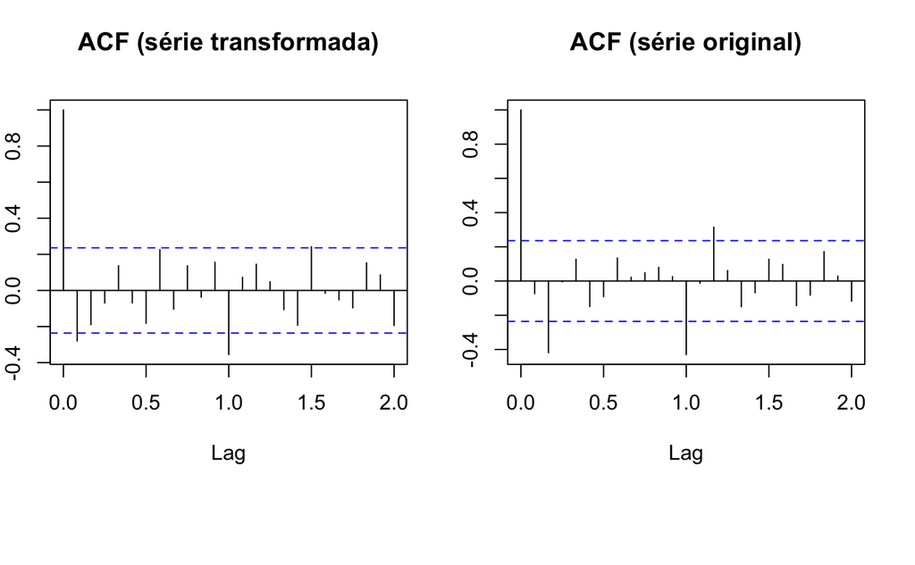

```r
par(mfrow = c(1, 1))
```

```r
par(mfrow = c(1, 2), mar = c(8, 2, 4, 2))
pacf(diff_transformed_y, main="PACF (série transformada)", lag.max=24)
pacf(diff_y_both_12_and_1, main="PACF (série original)", lag.max=24)
```

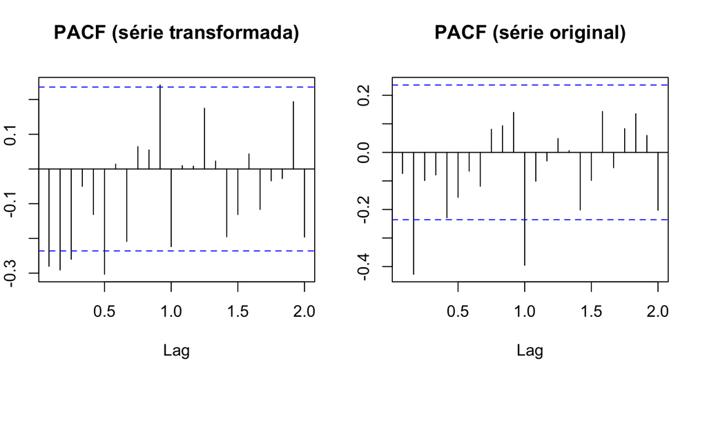

```r
par(mfrow = c(1, 1))
```

```r
sarima_model_t <- arima(transformed_y, order=c(0,1,1), seasonal=list(order=c(0,1,1), frequency=12))
sarima_model_t
```

```
Call:
arima(x = transformed_y, order = c(0, 1, 1), seasonal = list(order = c(0, 1,
    1), frequency = 12))

Coefficients:
          ma1     sma1
      -0.7022  -0.6780
s.e.   0.1165   0.1429

sigma^2 estimated as 0.426:  log likelihood = -72.48,  aic = 150.95
```

```r
coeftest(sarima_model_t)
```

```
z test of coefficients:

     Estimate Std. Error z value  Pr(>|z|)
ma1  -0.70221    0.11654 -6.0255 1.686e-09 ***
sma1 -0.67801    0.14288 -4.7452 2.083e-06 ***
---
Signif. codes:  0 ‘***’ 0.001 ‘**’ 0.01 ‘*’ 0.05 ‘.’ 0.1 ‘ ’ 1
```

```r
Box.test(sarima_model$residuals, lag = 15, type = "Ljung-Box")
```

```
    Box-Ljung test

data:  sarima_model$residuals
X-squared = 7.5406, df = 15, p-value = 0.9409
```

```r
Box.test(aa_model$residuals, lag = 15, type = "Ljung-Box")
```

```
    Box-Ljung test

data:  aa_model$residuals
X-squared = 5.4495, df = 15, p-value = 0.9876
```

```r
par(mfrow = c(1, 2), mar = c(8, 2, 4, 2))
acf(sarima_model_t$residuals, main="Resíduos SARIMA (0,1,1)(0,1,1)12")
acf(aa_model$residuals, main="Resíduos SARIMA (0,0,1)(2,1,0)12")
```

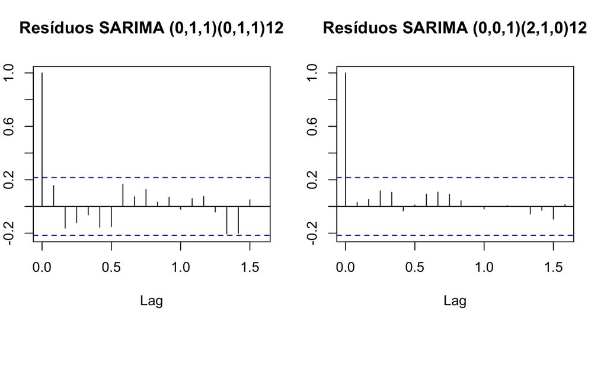

```r
par(mfrow = c(1, 1))
```

```r
par(mfrow = c(1, 2), mar = c(8, 2, 4, 2))
qqPlot(sarima_model_t$residuals, main="Resíduos SARIMA (0,1,1)(0,1,1)12")
```

```
[1] 70 64
```

```r
qqPlot(aa_model$residuals, main="Resíduos SARIMA (0,0,1)(2,1,0)12")
```

```
[1] 44 57
```

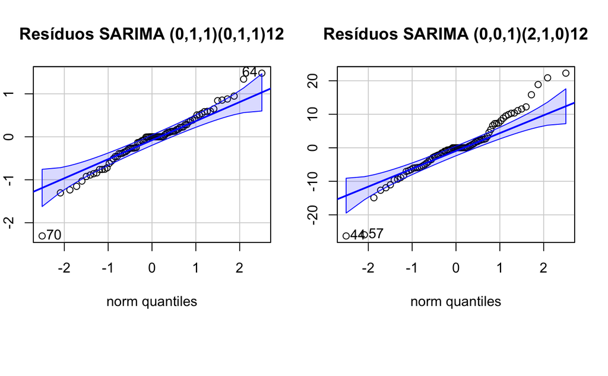

```r
par(mfrow = c(1, 1))
```

```r
nr_months <- 12

months_ahead_fc <- predict(sarima_model_t, n.ahead = nr_months)

ci <- 1.96

predicted <- exp(months_ahead_fc$pred) - 1

upper_bound <- months_ahead_fc$pred + ci * months_ahead_fc$se
lower_bound <- months_ahead_fc$pred - ci * months_ahead_fc$se

final_upper_bound <- exp(upper_bound) - 1
final_lower_bound <- exp(lower_bound) - 1

months_ahead_fc_aa <- predict(aa_model, n.ahead = nr_months)

upper_bound_aa <- months_ahead_fc_aa$pred + ci * months_ahead_fc_aa$se
lower_bound_aa <- months_ahead_fc_aa$pred - ci * months_ahead_fc_aa$se

par(mfrow = c(1, 2), mar = c(8, 2, 4, 2))
ts.plot(y, exp(transformed_y - residuals(sarima_model_t))-1, predicted, final_upper_bound, final_lower_bound, xlab="mês/ano", ylab="qty", lty=c(1,2,1,3,3), col=c("black", "red", "blue", "gray", "gray"), main="Previsão SARIMA(0,1,1)(0,1,1)12"); abline(h = 0, col = "black", lty = 4, lwd = 1)
legend("topleft",
       legend = c("observado", "previsto", "projetado"),
       col = c("black", "red", "blue"),
       lty = c(1, 2, 1),
       cex=0.6)
```

```r
ts.plot(y, (y - residuals(aa_model)), months_ahead_fc_aa$pred, upper_bound_aa, lower_bound_aa, xlab="mês/ano", ylab="qty", lty=c(1,2,1,3,3), col=c("black", "red", "blue", "gray", "gray"), main="Previsão SARIMA(0,0,1)(2,1,0)12"); abline(h = 0, col = "black", lty = 4, lwd = 1)
legend("topleft",
       legend = c("observado", "previsto", "projetado"),
       col = c("black", "red", "blue"),
       lty = c(1, 2, 1),
       cex=0.6)
```

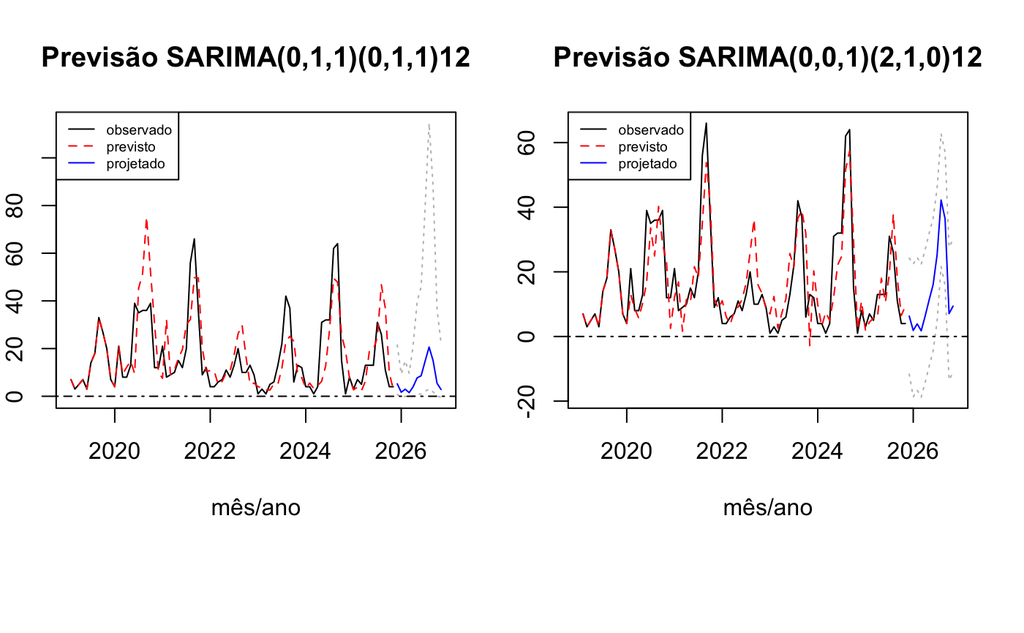

```r
par(mfrow = c(1, 1))
```

Notamos o efeito do uso da transformação de log(valor+1) e seu impacto tanto no intervalo de valores como também nos valores gerados. Passamos a ter um intervalo assimétrico para o primeiro modelo, além de projeçõe mais modestas e, de certa forma, otimistas quanto à baixa de ocorrências de incêndio. O modelo gerado por auto.arima, na série original, apresenta valores negativos previstos porém traz uma projeção mais condizente com o comportamento visto na série. Nota-se também que o intervalo de valores é simétrico.